# 03 Explorative Datenanalyse

### Libraries and settings

```python
# Libraries
import os
import re
import json
import time
import random
import pandas as pd
import pymysql
import numpy as np
import statsmodels.api as sm
import scipy.stats as stats

from sklearn.linear_model import LinearRegression

from sklearn.cluster import KMeans

from bs4 import BeautifulSoup

from prettytable import from_csv

import seaborn as sns
import matplotlib.pyplot as plt
import matplotlib.image as mpimg

from selenium import webdriver
from selenium.webdriver.common.by import By
from selenium.webdriver.common.keys import Keys
from selenium.webdriver.chrome.options import Options
from selenium.webdriver.chrome.service import Service
from selenium.webdriver.support.ui import WebDriverWait
from webdriver_manager.chrome import ChromeDriverManager
from selenium.webdriver.support import expected_conditions as EC

# Settings
import warnings
warnings.filterwarnings("ignore")

# Current working directory
print(f'Current working directory: {os.getcwd()}')
```

```
Current working directory: c:\Users\jalib\ZHAW\ZHAW-Privat - General\WINF Master\FS24\ADS\applied_data_science\Projektarbeit
```

### Connection mit der MySQL-Database

```python
import mysql.connector

#Verbindung mit der Datenbank wird hergestellt
conn = mysql.connector.connect(
  host="localhost",
  port=3306,
  user="admin",
  password="secret",
  database="mydatabase"
)
```

### Get Data from MySQL-Database

```python
from sqlalchemy import create_engine

# Daten holen und in einer Dataframe abspeichern
engine = create_engine('mysql+pymysql://admin:secret@localhost:3306/mydatabase')
df = pd.read_sql_query('SELECT * FROM apartment_table', con=engine)

# Anzahl der Zeilen in der DataFrame
num_rows = len(df)
print(f'Die Anzahl der Zeilen in der DataFrame beträgt: {num_rows}')

df.head(15)
```

```
Die Anzahl der Zeilen in der DataFrame beträgt: 829
```

|  | Page | Address | Rooms | Size | Price | Description | Weblink | Latitude | Longitude | Description_No_Stopwords | tokenized_description | stemmed_description | tfidf_best5 |
| --- | --- | --- | --- | --- | --- | --- | --- | --- | --- | --- | --- | --- | --- |
| 0 | 1 | Tösstalstrasse, 8405 Winterthur | 4.5 | 121.0 | 1110000.0 | Hier im Quartier Winterthur-Sennhof verabschie... | https://www.immoscout24.ch/kaufen/4000762004 | 47.487171 | 8.754987 | Hier Quartier Winterthur-Sennhof verabschiedet... | Hier, Quartier, Winterthur-Sennhof, verabschie... | hier quartier winterthur-sennhof verabschiedet... | sennhof, fernwärmesystem, bewährt, aufatmen, i... |
| 1 | 1 | Solistrasse 72, 8180 Bülach | 4.5 | 128.0 | 1402000.0 | Angegliedert an das neue Quartier Bülach Nord ... | https://www.immoscout24.ch/kaufen/4001029155 | 47.530853 | 8.540648 | Angegliedert neue Quartier Bülach Nord ( Nähe ... | Angegliedert, neue, Quartier, Bülach, Nord, (,... | angegliedert neue quartier bülach nord ( nähe ... | gemeinsam, freundinnen, kennt, typisch, interpret |
| 2 | 1 | Leuengasse, 8142 Uitikon | 3.5 | 96.0 | 1660000.0 | Keine typische Wohnung, wie man sie kennt. Ehe... | https://www.immoscout24.ch/kaufen/4000909024 | 47.368034 | 8.462051 | Keine typische Wohnung , kennt . Eher Individu... | Keine, typische, Wohnung, ,, kennt, ., Eher, I... | kein typisch wohnung , kennt . eher individual... | m², zimmerwohnungen, aussenflächen, entsteht, ... |
| 3 | 1 | Jakob-Fügli-Strasse 2, 8048 Zürich | 2.5 | 76.0 | 1250000.0 | Im beliebten Stadtteil Altstetten, nahe am Lin... | https://www.immoscout24.ch/kaufen/4001110845 | 47.389793 | 8.484723 | Im beliebten Stadtteil Altstetten , nahe Linde... | Im, beliebten, Stadtteil, Altstetten, ,, nahe,... | im beliebten stadtteil altstetten , nahe linde... | laufen, uhwiesen, schaffhausen, minuten, schne... |
| 4 | 1 | Nüsatzstrasse 11, 8248 Laufen-Uhwiesen | 4.5 | 123.0 | 1280000.0 | Im schönen Zürcher-Weinland, in unmittelbarer ... | https://www.immoscout24.ch/kaufen/4001029160 | 47.669262 | 8.639042 | Im schönen Zürcher-Weinland , unmittelbarer Na... | Im, schönen, Zürcher-Weinland, ,, unmittelbare... | im schönen zürcher-weinland , unmittelbar nach... | pp, zahnarztpraxis, denken, augenschein, mabag |
| 5 | 1 | Lagerhausweg 5, 8424 Embrach | 3.5 | 104.0 | 1051000.0 | Wir realisieren an zentraler Lage in Embrach e... | https://www.immoscout24.ch/kaufen/4001088189 | 47.500591 | 8.597564 | Wir realisieren zentraler Lage Embrach MFH tot... | Wir, realisieren, zentraler, Lage, Embrach, MF... | wir realisieren zentral lage embrach mfh total... | m2, 13, ausflugsort, qualitäten, centrolago |
| 6 | 1 | Seestrasse 123, 8820 Wädenswil | 3.5 | 98.0 | 1295000.0 | Auf Sommer 2025 entstehen an ausgezeichneter L... | https://www.immoscout24.ch/kaufen/4000389488 | 47.230598 | 8.673362 | Auf Sommer 2025 entstehen ausgezeichneter Lage... | Auf, Sommer, 2025, entstehen, ausgezeichneter,... | auf sommer 2025 entstehen ausgezeichnet lage 1... | soeben, terrassiert, hgvfür, fertiggestellt, e... |
| 7 | 1 | Dammstrasse 2, 8180 Bülach | 3.5 | 107.0 | 1525000.0 | Zwischen Bahnhof und Altstadt erstellen wir di... | https://www.immoscout24.ch/kaufen/4001029161 | 47.521919 | 8.539837 | Zwischen Bahnhof Altstadt erstellen attraktive... | Zwischen, Bahnhof, Altstadt, erstellen, attrak... | zwischen bahnhof altstadt erstellen attrakt üb... | ansprüche, anspielungen, preislist, einbringen... |
| 8 | 1 | Oberseenerstrasse 46, 8405 Winterthur | 4.5 | 234.0 | 1765000.0 | Dieses Haus wurde soeben fertiggestellt. Der g... | https://www.immoscout24.ch/kaufen/4001109702 | 47.480427 | 8.768223 | Dieses Haus wurde soeben fertiggestellt . Der ... | Dieses, Haus, wurde, soeben, fertiggestellt, .... | dies hau wurd soeben fertiggestellt . der ganz... | laufen, uhwiesen, schaffhausen, minuten, schne... |
| 9 | 1 | Spyristrasse 34, 8044 Zürich | 3.5 | 101.0 | 2680000.0 | Mitten im beliebten Wohnquartier Fluntern ents... | https://www.immoscout24.ch/kaufen/3002233412 | 47.382797 | 8.553283 | Mitten beliebten Wohnquartier Fluntern entsteh... | Mitten, beliebten, Wohnquartier, Fluntern, ent... | mitten beliebten wohnquarti fluntern entstehen... | häuser, projekt, einbetten, beigemessen, neuwi... |
| 10 | 1 | Nüsatzstrasse 11, 8248 Laufen-Uhwiesen | 3.5 | 93.0 | 850000.0 | Im schönen Zürcher-Weinland, in unmittelbarer ... | https://www.immoscout24.ch/kaufen/4001029159 | 47.669262 | 8.639042 | Im schönen Zürcher-Weinland , unmittelbarer Na... | Im, schönen, Zürcher-Weinland, ,, unmittelbare... | im schönen zürcher-weinland , unmittelbar nach... | minergi, pp, augenschein, manag, denken |
| 11 | 1 | Pfannenstielstrasse 112, 8706 Meilen | 4.5 | 114.0 | 2100000.0 | Willkommen an der Pfannenstielstrasse 112! Hie... | https://www.immoscout24.ch/kaufen/4001110551 | 47.270844 | 8.653910 | Willkommen Pfannenstielstrasse 112 ! Hier ents... | Willkommen, Pfannenstielstrasse, 112, !, Hier,... | willkommen pfannenstielstrass 112 ! hier entst... | pp, zahnarztpraxis, denken, augenschein, mabag |
| 12 | 1 | Im Eichbühl 54, 8405 Winterthur | 5.5 | 136.0 | 1990000.0 | An südöstlich privilegierter Hanglage von Wint... | https://www.immoscout24.ch/kaufen/4001043871 | 47.485744 | 8.773448 | An südöstlich privilegierter Hanglage Winterth... | An, südöstlich, privilegierter, Hanglage, Wint... | an südöstlich privilegiert hanglag winterthur ... | maisonett, aentenschnabel, chhaben, objektwebs... |
| 13 | 1 | Lagerhausweg 5, 8424 Embrach | 4.5 | 120.0 | 1294000.0 | Wir realisieren an zentraler Lage in Embrach e... | https://www.immoscout24.ch/kaufen/4001088187 | 47.500591 | 8.597564 | Wir realisieren zentraler Lage Embrach MFH tot... | Wir, realisieren, zentraler, Lage, Embrach, MF... | wir realisieren zentral lage embrach mfh total... | m², wigarteweg, 00, löwen, projektierten |
| 14 | 1 | Rieterstrasse 102, 8002 Zürich | 1.5 | 44.0 | 980000.0 | An äusserst attraktiver Wohnlage im Zürcher En... | https://www.immoscout24.ch/kaufen/4000707683 | 47.353458 | 8.526158 | An äusserst attraktiver Wohnlage Zürcher Enge-... | An, äusserst, attraktiver, Wohnlage, Zürcher, ... | an äusserst attraktiv wohnlag zürcher enge-qua... | puurehuu, wermatswil, herz, neubau, herzen |

## Explorative Datenanalyse (EDA)

## Analyse Preis

### Univariate Non-Graphical Analysis

```python
# Central Tendency
mean_value = df['Price'].mean()
median_value = df['Price'].median()
mode_value = df['Price'].mode()

print("Mean: ", mean_value)
print("Median: ", median_value)
print("Mode: ", mode_value)

# Dispersion
variance_value = df['Price'].var()
std_deviation = df['Price'].std()

print("Variance: ", variance_value)
print("Standard Deviation: ", std_deviation)

# Skewness and Kurtosis
skewness_value = df['Price'].skew()
kurtosis_value = df['Price'].kurt()

print("Skewness: ", skewness_value)
print("Kurtosis: ", kurtosis_value)
```

```
Mean:  1347378.3989834816
Median:  1285000.0
Mode:  0    895000.0
Name: Price, dtype: float64
Variance:  261751688362.31894
Standard Deviation:  511616.73972058314
Skewness:  0.6093904751239604
Kurtosis:  -0.30478147792730015
```

### Univariate Graphical Analysis

Histogram

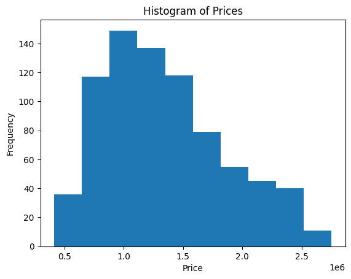

```python
# Histogram
plt.hist(df['Price'])
plt.title('Histogram of Prices')
plt.xlabel('Price')
plt.ylabel('Frequency')
plt.show()
```

Das Histogramm zeigt die Verteilung der Wohnungspreise. Die meisten Wohnungspreise liegen im Bereich von etwa 0,8 bis 1,6 Millionen, was durch die Berechnungen der univariaten Analyse unterstützt wird. Der Durchschnittspreis der Wohnungen beträgt etwa 1'347'378.40, und der Median liegt bei 1'285'000 was die Konzentration der Preise in diesem mittleren Bereich bestätigt.

Es gibt weniger Wohnungen, deren Preise höher oder niedriger als dieser Bereich sind, was eine rechtschiefe Verteilung (positive Schiefe von 0.609) andeutet. Diese positive Schiefe bedeutet, dass es mehr niedrigere Preise gibt, aber einige hohe Ausreisser existieren, was im Histogramm durch den längeren rechten Schwanz dargestellt wird. Die Standardabweichung von 511'616.74 und die Varianz von 261'751'688'362.32 zeigen, dass die Preise um diesen Mittelwert stark streuen. Die leicht negative Kurtosis von -0.305 deutet darauf hin, dass die Verteilung flacher als eine Normalverteilung ist, mit weniger extremen Werten als eine typische Normalverteilung. Dies bedeutet, dass die Mehrheit der Wohnungen in einem mittleren Preissegment liegt, während es weniger Wohnungen gibt, die sehr günstig oder sehr teuer sind.

Boxplot

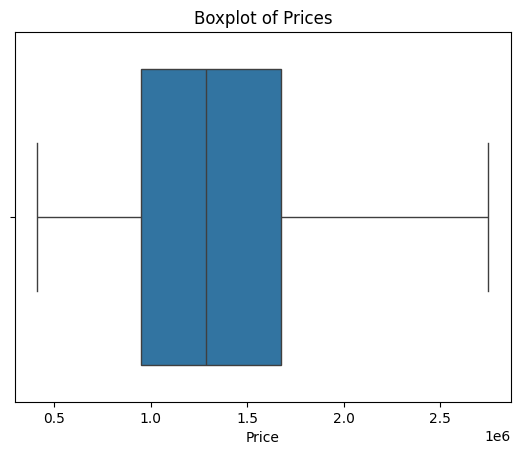

```python
# Boxplot
sns.boxplot(x=df['Price'])
plt.title('Boxplot of Prices')
plt.xlabel('Price')
plt.show()
```

Der Boxplot ergänzt das Histogramm und bietet eine visuelle Darstellung der Verteilung der Wohnungspreise, ihrer Streuung und möglicher Ausreisser. Die Box stellt den Interquartilsabstand (IQR) dar, der die mittleren 50% der Daten abdeckt, während die Linie innerhalb der Box den Median bei ca. 1'285'000 markiert. Der Durchschnittspreis der Wohnungen beträgt ca. 1'347'378.40, was leicht über dem Median liegt und auf eine leicht positive Schiefe der Verteilung hinweist.

## Analyse des Zusammenhangs von Preis und Grösse

### Scatter Plot (Preis vs Grösse)

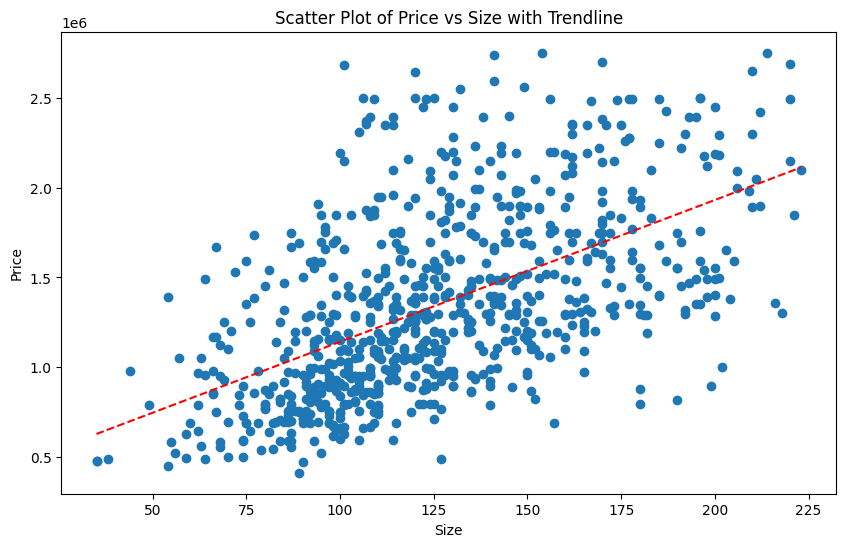

```python
# Daten sortieren nach Grösse
df = df.sort_values(by='Size')

# Scatter Plot von Preis vs Grösse
plt.figure(figsize=(10, 6))  # Ändere die Grösse des Plots
plt.scatter(df['Size'], df['Price'])
# Berechne die Trendlinie
z = np.polyfit(df['Size'], df['Price'], 1)
p = np.poly1d(z)

# Zeichne die Trendlinie
plt.plot(df['Size'], p(df['Size']), "r--")

plt.xlabel('Size')
plt.ylabel('Price')
plt.title('Scatter Plot of Price vs Size with Trendline')
plt.show()
```

Das Streudiagramm zeigt den Zusammenhang zwischen Preis und Wohnungsgrösse. Es ist eine positive Korrelation zu erkennen, d.h. je grösser die Wohnung, desto höher der Preis. Die Trendlinie verstärkt diesen Zusammenhang, indem sie die allgemeine Tendenz der Datenpunkte hervorhebt. Einige Ausreisser weisen darauf hin, dass es Wohnungen gibt, die trotz ähnlicher Grösse sehr unterschiedliche Preise haben.

### Hexagonal Binning Plot (Preis vs Grösse)

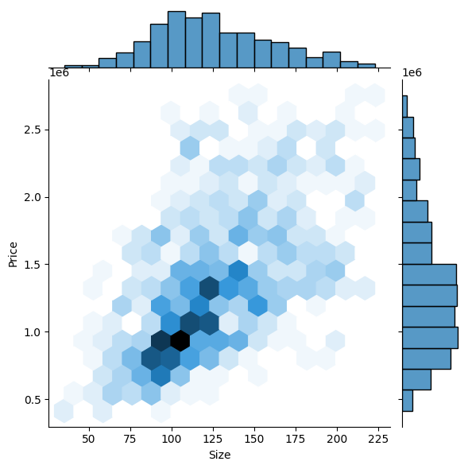

```python
# Hexagonal Binning Plot
sns.jointplot(x='Size', y='Price', kind="hex", data=df[['Size', 'Price', 'Rooms']])
plt.show()
```

Das Hexbin-Diagramm ergänzt das obige Streudiagramm und bietet zusätzliche Einblicke in die Verteilung der Daten. Neben der bereits beobachteten positiven Korrelation zwischen Preis und Wohnungsgrösse zeigt das Hexbin-Diagramm die Dichte der Datenpunkte anhand der Farbintensität der Hexagone. Dunklere Farben bedeuten eine höhere Konzentration von Datenpunkten, was hilft, Gebiete mit besonders vielen Datenpunkten zu identifizieren.

Zusätzlich zeigen die Histogramme am oberen und rechten Rand des Diagramms die Randverteilungen von Grösse und Preis getrennt an. Diese Histogramme bestätigen die zuvor beobachteten Verteilungen, dass die meisten Wohnungen mittlere Grössen und Preise haben.

Das Hexbin-Diagramm zeigt, dass die meisten Datenpunkte im Bereich von etwa 100 bis 125 Quadratmetern und Preisen zwischen etwa 0,8 und 1,5 Millionen liegen. Diese Beobachtung unterstreicht die bereits im Streudiagramm erkennbare Tendenz und bietet eine deutlichere Visualisierung der Dichte, die im Streudiagramm weniger offensichtlich ist. Insgesamt bestätigt das Hexbin-Diagramm die positive Korrelation zwischen Preis und Grösse und zeigt, dass die Mehrheit der Datenpunkte in einem mittleren Bereich zwischen Preis und Grösse liegt.

## Analyse des Zusammenhangs von Preis und Anzahl Zimmer

### Balkendiagramm (Preis vs Anzahl Zimmer)

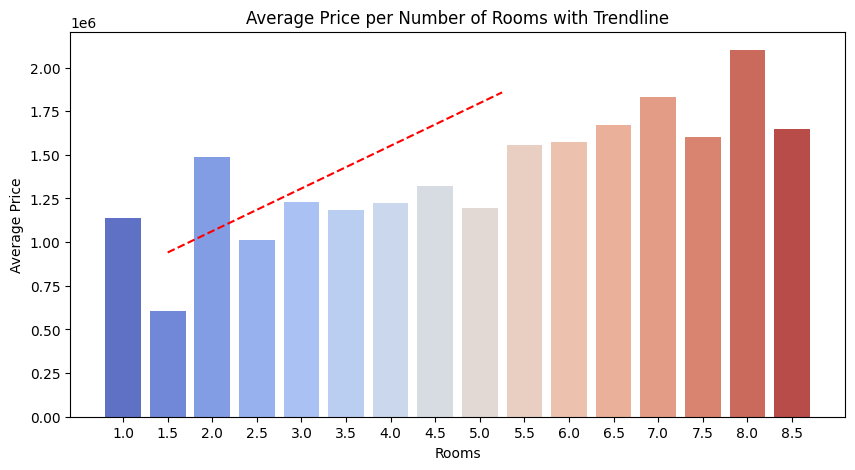

```python
# Durchschnittspreis pro Anzahl der Zimmer berechnen
mean_price_per_room = df.groupby('Rooms')['Price'].mean().reset_index()

# Balkendiagramm erstellen
plt.figure(figsize=(10, 5))
sns.barplot(x='Rooms', y='Price', data=mean_price_per_room, palette='coolwarm')

# Trendlinie hinzufügen
X = mean_price_per_room[['Rooms']]
y = mean_price_per_room['Price']
model = LinearRegression().fit(X, y)
trendline = model.predict(X)
plt.plot(mean_price_per_room['Rooms'], trendline, "r--")

plt.xlabel('Rooms')
plt.ylabel('Average Price')
plt.title('Average Price per Number of Rooms with Trendline')
plt.show()
```

Das Balkendiagramm zeigt den durchschnittlichen Preis in Abhängigkeit von der Anzahl der Zimmer in Wohnungen. Es lässt sich beobachten, dass der durchschnittliche Preis im Allgemeinen mit der Anzahl der Zimmer steigt, was durch die steigende Trendlinie verdeutlicht wird. Besonders auffällig ist, dass Wohnungen mit 1,5 Zimmern deutlich günstiger sind, während Wohnungen mit 8 Zimmern den höchsten Durchschnittspreis aufweisen.

### Korrelationsmatrix

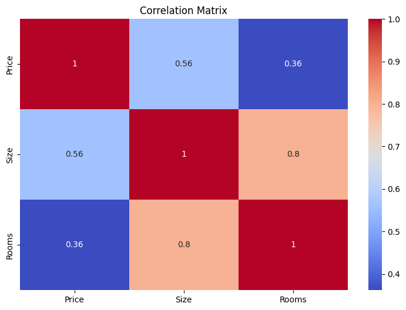

```python
# Korrelationsmatrix
corr_matrix = df[['Price', 'Size', 'Rooms']].corr()
plt.figure(figsize=(9, 6))  # Ändere die Grösse des Plots
sns.heatmap(corr_matrix, annot=True, cmap='coolwarm')
plt.title('Correlation Matrix')
plt.show()
```

Die Korrelationsmatrix zeigt den Zusammenhang zwischen Preis, Grösse und Zimmerzahl der Wohnungen. Es ist ersichtlich, dass die Grösse (Size) eine moderate Korrelation von 0,56 mit dem Preis (Price) aufweist, was bedeutet, dass grössere Wohnungen tendenziell teurer sind. Die Anzahl der Zimmer (Rooms) weist eine stärkere Korrelation von 0,8 mit der Grösse auf, was darauf hindeutet, dass grössere Wohnungen in der Regel mehr Zimmer haben. Die Korrelation zwischen der Anzahl der Zimmer und dem Preis beträgt 0,36, was eine schwächere, aber immer noch positive Beziehung darstellt. Diese Werte bestätigen die bisherigen Beobachtungen, dass Preis, Grösse und Zimmerzahl miteinander zusammenhängen, wobei die stärkste Beziehung zwischen Grösse und Zimmerzahl besteht.

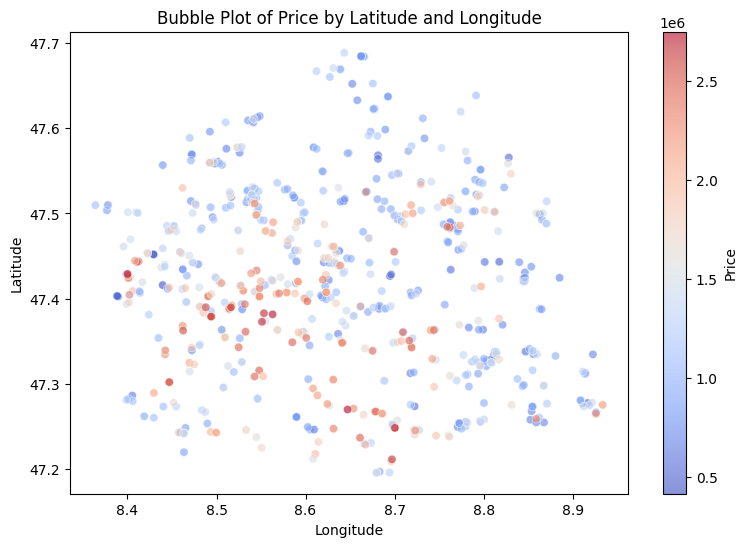

```python
# Bubble Plot von Latitude, Longitude und Preis mit Farbverlauf
plt.figure(figsize=(9, 6))  # Ändere die Grösse des Plots
sc = plt.scatter(df['Longitude'], df['Latitude'], c=df['Price'], cmap='coolwarm', alpha=0.6, edgecolors='w', linewidth=0.5)
plt.colorbar(sc, label='Price')
plt.xlabel('Longitude')
plt.ylabel('Latitude')
plt.title('Bubble Plot of Price by Latitude and Longitude')
plt.show()
```

Die Analyse der geografischen Verteilung der Wohnungspreise in Zürich und Umgebung liefert wertvolle Einblicke in die Preisstruktur der Region. Das Bubble Plot zeigt die Preise der Wohnungen anhand farbiger Blasen, wobei die Farbskala die Preishöhe darstellt (hellere Farben für niedrigere Preise und dunklere Farben für höhere Preise). Die Verteilung der Blasen auf den Koordinaten (Breite und Länge) bietet eine visuelle Darstellung der Preisverteilung. Hierbei ist erkennbar, dass die teureren Wohnungen (dunkelrote Blasen) sich tendenziell in bestimmten Gebieten häufen, während die günstigeren Wohnungen (hellblaue Blasen) in anderen Bereichen verstreut sind.

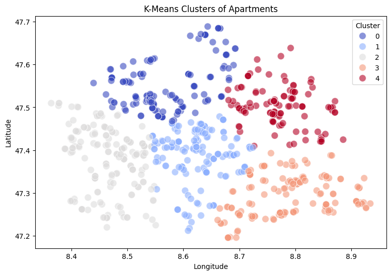

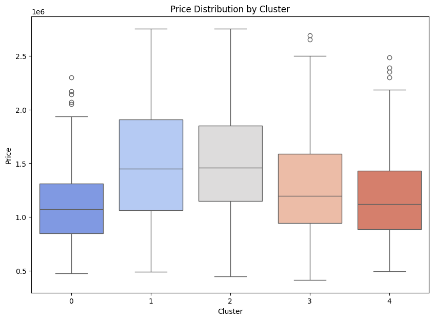

```python
# K-Means Clustering
coordinates = df[['Latitude', 'Longitude']]
kmeans = KMeans(n_clusters=5, random_state=42).fit(coordinates)
df['Cluster'] = kmeans.labels_

# Visualisierung der Cluster
plt.figure(figsize=(9, 6))
sns.scatterplot(x='Longitude', y='Latitude', hue='Cluster', palette='coolwarm', data=df, alpha=0.6, edgecolor='w', s=100)
plt.xlabel('Longitude')
plt.ylabel('Latitude')
plt.title('K-Means Clusters of Apartments')
plt.show()

# Analyse der Preismuster innerhalb der Cluster
plt.figure(figsize=(10, 7))
sns.boxplot(x='Cluster', y='Price', data=df, palette='coolwarm')
plt.xlabel('Cluster')
plt.ylabel('Price')
plt.title('Price Distribution by Cluster')
plt.show()
```

Das Boxplot-Diagramm der Preisverteilung innerhalb der Cluster bietet weitere Einblicke in die Preisstruktur. Einige Cluster weisen höhere Medianpreise und grössere Preisstreuungen auf, was auf eine breite Preisspanne in diesen Gebieten hinweist. Andere Cluster weisen eine engere Preisverteilung auf, was auf homogenere Preisstrukturen in diesen Gebieten schliessen lässt.

#### Erkenntnisse

Die Stadt Zürich hat die Koordinaten 47.3769° N und 8.5417° E. Diese zentrale Lageinformationen ermöglichen es, die genaue Position der teureren und günstigeren Wohnungen in Bezug auf das Stadtzentrum von Zürich zu identifizieren. Es lässt sich feststellen, dass Wohnungen in der Nähe des Stadtzentrums von Zürich (Koordinaten 47.3769° N, 8.5417° E) tendenziell teurer sind. Dies umfasst die Bezirke 1 (Altstadt), 2 (Enge), 8 (Riesbach) und Teile von 7 (Fluntern, Hottingen). Bereiche entlang des Zürichsees, insbesondere auf der rechten (Goldküste) und linken Seeseite (Silberküste), wie Küsnacht, Zollikon und Erlenbach, zeigen höhere Preise aufgrund der begehrten Seelage. Stadtteile wie Seefeld (Teil von Riesbach) und Zürichberg (Teil von Fluntern und Hottingen) sind bekannt für exklusive Wohnlagen mit hohen Immobilienpreisen.

Zusammengefasst zeigt die Analyse, dass die teuersten Wohnungen im Stadtzentrum, in seenahen Lagen und in noblen Wohnvierteln zu finden sind. Günstigere Wohnungen befinden sich tendenziell in den peripheren Gebieten, nordöstlichen Vororten und in der Nähe von Industriegebieten. Diese Erkenntnisse verdeutlichen die klare geografische Preisstruktur, die für die Stadtplanung und die Entwicklung von Wohnbauprojekten von Bedeutung ist.

### Jupyter notebook --footer info-- (please always provide this at the end of each notebook)

```python
import os
import platform
import socket
from platform import python_version
from datetime import datetime

print('-----------------------------------')
print(os.name.upper())
print(platform.system(), '|', platform.release())
print('Datetime:', datetime.now().strftime("%Y-%m-%d %H:%M:%S"))
print('Python Version:', python_version())
print('-----------------------------------')
```

```
-----------------------------------
NT
Windows | 10
Datetime: 2024-03-08 22:18:27
Python Version: 3.11.7
-----------------------------------
```